# 第10回 主成分の地図を読む

## 読者への説明

6節 ② 2台●●●●●●

カローラ1200は地図の左端近く、小さくて燃費のよい車の代表。インパラは右端近く、大きくてパワーのある車の代表で、すばやく加速する側にいる。

## TODO⑤：いちばん上の車

6節 ③ いちばん上●○○○

```python
# TODO: 第2主成分の得点がいちばん大きい車を探す
# ヒント: j = np.argmax(S[:, 1])
#         print(cars.loc[j, ['車名', '年式', '地域', '加速']])
#         print(S[j, :2].round(2))
...
```

- 加速がいちばんゆるやかな側の車

## やってみよう：6節とTODO⑤

6節 ③ いちばん上●●○○

- 6節のお手本を実行し、カローラの位置を手で計算する
- TODO⑤で、地図のいちばん上の車を探す

動画の人は、ここで一時停止。

## 答え合わせ：TODO⑤

6節 ③ いちばん上●●●○

```python
j = np.argmax(S[:, 1])
print(cars.loc[j, ['車名', '年式', '地域', '加速']])
print(S[j, :2].round(2))
```

```
車名    peugeot 504
年式           1979
地域          ヨーロッパ
加速           24.8
[-2.04  2.91]
```

## プジョー504

6節 ③ いちばん上●●●●

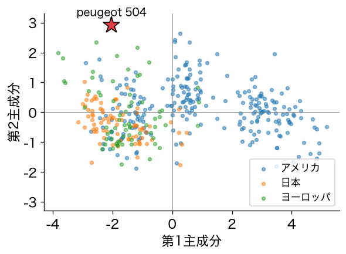

- 1979年、ヨーロッパ。加速は24.8秒。第2主成分2.91、第1主成分−2.04。小さめで、加速のとてもゆるやかな車

## 答え：2本の軸

6節 ④ 答え●○○

- 標準化した6列の主成分分析で、2本の軸が散らばりの91.9%を表す
- 横の軸（0.798）：気筒数・排気量・馬力・重さと、逆の燃費。「大きさ・パワーの軸」
- 縦の軸（0.121）：加速の負荷量0.893。「加速のゆるやかさの軸」

## 答え：1台の説明

6節 ④ 答え●●○

- カローラ1200は左端近く（−2.71, 0.39）の小さく燃費のよい車
- インパラは右端近く（4.92, −1.37）の大きくパワーのある車

## 答え：標準化

6節 ④ 答え●●●

- 単位がまちまちな列は、標準化してから主成分分析をする
- 標準化しないと、単位の選び方で、第1主成分が排気量にも重さにもなった

## まだ言えないこと①：残り

6節 ⑤ まだ言えないこと●○○

- 燃費の2割ほどなど、3本目より先の軸の違いは、この地図に表れない

## まだ言えないこと②：名前

6節 ⑤ まだ言えないこと●●○

- 軸の名前は、負荷量を見て付けたあだ名
- 車を何台か入れ替えると、第2主成分の向きが変わることもありうる

## まだ言えないこと③：年式

6節 ⑤ まだ言えないこと●●●

- 今日の6列には、年式を入れていない
- 年代による変化は、この地図では読めない

# まとめ

## 今日の道筋を振り返る

⑥ 振り返る●○○○○○

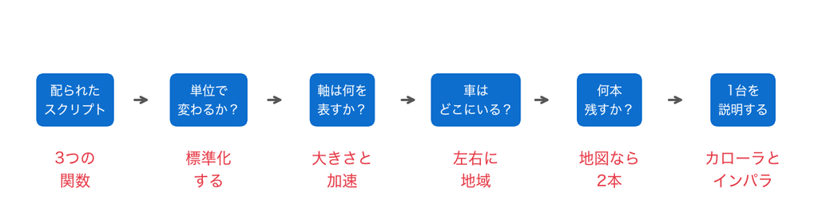

- 6つの小さな問いに答えて、地図の読み方が分かった

## 今日の歩み

⑥ 振り返る●●○○○○

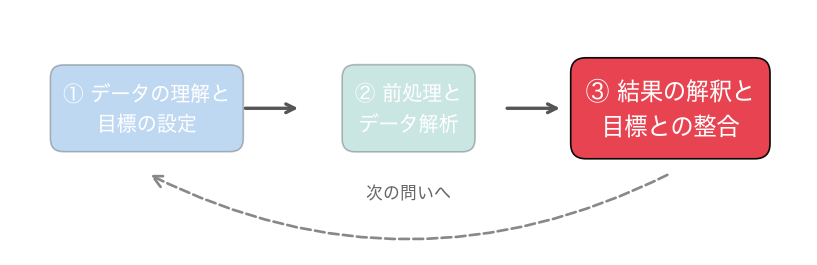

スクリプト → 単位と標準化 → 負荷量 → バイプロット → 本数 → 1台の説明

## 今日持ち帰る1文

⑥ 振り返る●●●○○○

単位がまちまちな列は、標準化してから主成分分析をする。軸は負荷量（得点を作るときの各列の重み）で読み、名前を付ける。2本の地図は近似なので、どれだけ残せているかを寄与率と矢印の長さで確かめてから説明に使う。

## 今日の要点①：単位と負荷量

⑥ 振り返る●●●●○○

- 標準化しないと、数の大きい列が第1主成分を占める
- 負荷量は得点を作るときの重み。相関は、負荷量×得点の標準偏差
- 符号に意味はない。どの列が同じ符号で並ぶかを読む

## 今日の要点②：地図

⑥ 振り返る●●●●●○

- バイプロット：点は車、矢印は列。矢印の向きの車ほど、その列が大きい
- 矢印の角度は相関の目安、長さは2本で残せている割合
- 本数の目安は食い違うことがある。目的に合わせて選ぶ

## 今日の要点③：Python

⑥ 振り返る●●●●●●

- 関数は、まずdocstringと引数・返す値（役割・入力・出力）を読む
- 既定値のある引数（`scale=True`）は、書き換えて使える
- 2つの値を返す関数は、`pca, S = ...`と並べて受け取る

## 課題の出し方

⑦ このあと●○○○

- ノートの最後の「課題（提出）」に取り組む
- 応用②の答えと応用③の文章を、LACSに入力して提出（＝出席。期限なし）
- AIを使ってもよい。何を聞いて、どう直したかを1行書く

## 次回予告：分ける

⑦ このあと●●○○

- 地図の上では、アメリカ車と、日本・ヨーロッパ車が左右に分かれて見えた
- 地域の列を使わなかったら、車はいくつのまとまりに分かれるか

## 次回の問い

⑦ このあと●●●○

答えの列を使わずに、データをいくつかのグループに分けるには、どうすればよいか？

## このあと：課題へ

⑦ このあと●●●●

ノートの「課題（提出）」へ。`fit_pca`の列に年式を足して、地図を作り直します。

# ここから先は解答

## 課題のあとで見る

課題（提出）に取り組んでから見てください。動画の人は、ここで一時停止。

## 応用①：年式を足す

```python
FEAT7 = FEAT + ['年式']
pca7, S7 = fit_pca(cars, FEAT7)
print(pca7.explained_variance_ratio_[:3].round(3))
load7 = pd.DataFrame(pca7.components_[:2].T, index=FEAT7,
                     columns=['第1', '第2'])
print(load7.round(3))
```

```
[0.716 0.124 0.104]
        第1     第2
燃費  -0.398  0.207
気筒数  0.416  0.199
排気量  0.429  0.180
馬力   0.423  0.085
重さ   0.414  0.225
加速  -0.285 -0.007
年式  -0.230  0.910
```

## 引数を変えるだけ

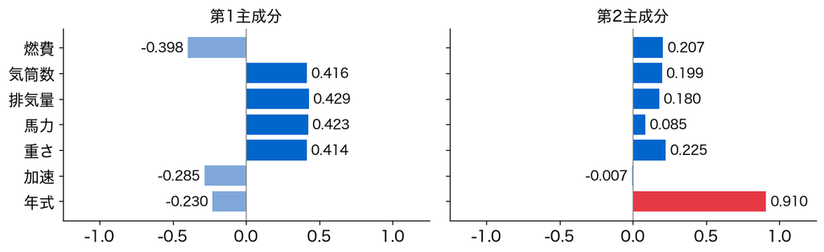

- 列のリストを変えて、同じ関数を呼び直した

## 応用②：答えは年式

```python
print('答え:', load7['第2'].abs().idxmax())
```

```
答え: 年式
```

- 第2主成分は年式（0.91）の軸に変わった。加速は第2主成分からほぼ消える

## 応用③：模範例

横の軸は車の大きさとパワー（右ほど大きく重く、燃費が悪い）、縦の軸は加速のゆるやかさ（上ほど時速60マイルまでに時間がかかる）を表します。この2本の軸で、6つの性能の散らばりの9割（91.9%）を表せていて、どの性能も8割以上が地図に残っています。ただし、燃費の2割ほどや、年式による違いはこの地図には表れていないので、細かい比較には元の性能表もあわせて見てください。

## 書き方の型

- 1文目：2本の軸が何を表すか（読者の言葉で）
- 2文目：地図がどれだけ残しているか（数で）
- 3文目：地図に表れないこと

# 発展（任意）

## 近所だけを守る地図

- 主成分分析の地図は、散らばりをできるだけ多く残す向きで描いた
- 「近くにいる車どうしを、地図の上でも近くに置く」ことだけを目指す方法もある
- その代表がt-SNE

## お手本：t-SNEで描く

```python
from sklearn.manifold import TSNE
Z = StandardScaler().fit_transform(cars[FEAT])
T = TSNE(perplexity=30, random_state=0).fit_transform(Z)
fig, axes = plt.subplots(1, 2, figsize=(11, 4.5))
for g in ['アメリカ', '日本', 'ヨーロッパ']:
    m = (cars['地域'] == g).values
    axes[0].scatter(S[m, 0], S[m, 1], s=10, alpha=0.5, label=g)
    axes[1].scatter(T[m, 0], T[m, 1], s=10, alpha=0.5, label=g)
axes[0].set_title('主成分分析')
axes[1].set_title('t-SNE')
axes[0].legend()
plt.show()
```

- `perplexity`：何台くらいを「近所」とみなすかの目安（既定値は30）

## 島に分かれて見える

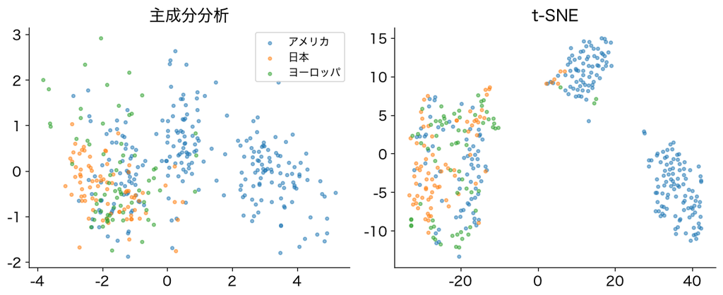

## 軸に意味はない

- t-SNEの横と縦の軸には、負荷量のような意味がない
- 島どうしの離れ具合も、性能の違いの大きさとは限らない

## お手本：距離を比べる

```python
from sklearn.metrics import pairwise_distances
D = pairwise_distances(Z)
up = np.triu_indices(len(Z), 1)
D_pca = pairwise_distances(S[:, :2])
D_tsne = pairwise_distances(T)
print(np.corrcoef(D[up], D_pca[up])[0, 1].round(3))
print(np.corrcoef(D[up], D_tsne[up])[0, 1].round(3))
```

- すべての2台の組で、元の距離と地図の上の距離の相関を出す

## 主成分0.993、t-SNE0.913

```
0.993
0.913
```

- 主成分分析の地図は、遠い車を地図でも遠く置く
- t-SNEは、近所の並びを優先し、遠い車どうしの距離は保たない

## 近所を狭くすると

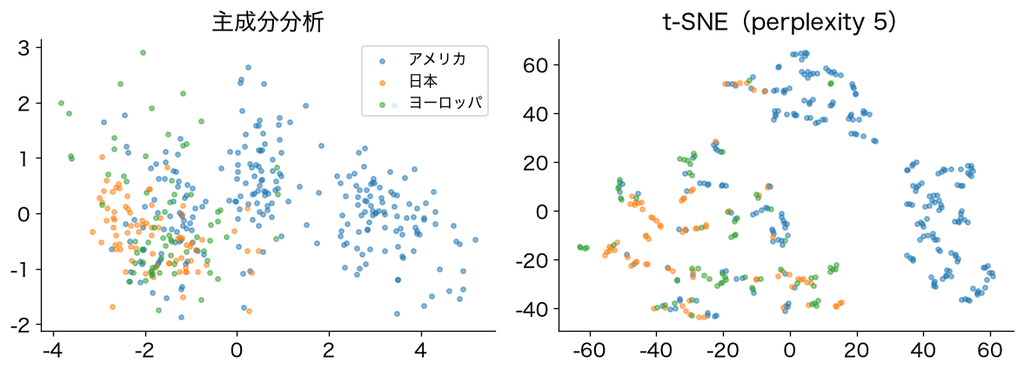

```
0.726
```

- `perplexity=5`では島が細かく分かれ、距離の相関は0.726に下がる

## 試すなら

- `!pip install -q umap-learn`でUMAPを入れる
- `umap.UMAP(random_state=0).fit_transform(Z)`で、同じ比べ方ができる

## おわり

- 今日は、392台の車を、2本の軸の地図にして読んだ
- 標準化し、負荷量で軸に名前を付け、1台を軸の名前で説明した